# Computing Assessment

```r
library(tidyr)
library(readr)
library(dplyr)
library(ggplot2)
library(stringr)
library(lubridate)
```

# R Programming Part 1

For this portion of the assessment, we will be working with the MPG dataset. To answer the questions, you will need to complete the following tasks: - Read the “Auto_MPG_Exam.csv” data. Name your data df_auto. Ensure stringAsFactors=FALSE - Create a column named “Car_Make” from the first element of the “Car_Name” variable - Update “horsepower” to be type numeric - Change the type of “Cylinders”, “Model_Year”, and “Origin” from numeric to character (Hint: you will need to use the as.character function)

```r
df_auto$Horsepower <- as.numeric(df_auto$Horsepower)
df_auto$Cylinders <- as.character(df_auto$Cylinders)
df_auto$Model_Year <- as.character(df_auto$Model_Year)
df_auto$Origin <- as.character(df_auto$Origin)
```

## Question 16

How many unique values of “Car_Make” are there?

```r
n_distinct(df_auto$Car_Make)
```

```
[1] 37
```

## Question 17

How many variables in “df_auto” are of type character?

```r
str(df_auto)
```

```
spc_tbl_ [398 × 10] (S3: spec_tbl_df/tbl_df/tbl/data.frame)
 $ MPG         : num [1:398] 18 15 18 16 17 15 14 14 14 15 ...
 $ Cylinders   : chr [1:398] "8" "8" "8" "8" ...
 $ Displacement: num [1:398] 307 350 318 304 302 429 454 440 455 390 ...
 $ Horsepower  : num [1:398] 130 165 150 150 140 198 220 215 225 190 ...
 $ Weight      : num [1:398] 3504 3693 3436 3433 3449 ...
 $ Acceleration: num [1:398] 12 11.5 11 12 10.5 10 9 8.5 10 8.5 ...
 $ Model_Year  : chr [1:398] "70" "70" "70" "70" ...
 $ Origin      : chr [1:398] "1" "1" "1" "1" ...
 $ Car_Name    : chr [1:398] "chevrolet chevelle malibu" "buick skylark 320" "plymouth satellite" "amc rebel sst" ...
 $ Car_Make    : chr [1:398] "chevrolet" "buick" "plymouth" "amc" ...
 - attr(*, "spec")=
  .. cols(
  ..   MPG = col_double(),
  ..   Cylinders = col_double(),
  ..   Displacement = col_double(),
  ..   Horsepower = col_character(),
  ..   Weight = col_double(),
  ..   Acceleration = col_double(),
  ..   Model_Year = col_double(),
  ..   Origin = col_double(),
  ..   Car_Name = col_character()
  .. )
 - attr(*, "problems")=<externalptr>
```

```r
univariate_analysis <- function(data) {
  obs = length(data)
  mean = mean(data, na.rm = TRUE)
  stdev = sd(data, na.rm = TRUE)
  quartiles = quantile(data, probs=c(0, 0.25, 0.5, 0.75, 1), na.rm = TRUE)
  return(list(obs, mean, stdev, quartiles))
}
```

## Question 18

Using the function created, what is the 2nd quartile (the median, the 50th percentile) of “MPG”?

```r
univariate_analysis(df_auto$MPG)
```

```
[[1]]
[1] 398

[[2]]
[1] 23.51457

[[3]]
[1] 7.815984

[[4]]
  0%  25%  50%  75% 100%
 9.0 17.5 23.0 29.0 46.6
```

To the “univariate_analysis” function, create a histogram plot named “histogram” using the code provided below. Add the plot to the return list with the element named “histogram”:

histogram <- ggplot(data=data.frame(x=data), aes(x=x)) + geom_histogram()

```r
univariate_analysis <- function(data) {
  obs = length(data)
  mean = mean(data, na.rm = TRUE)
  stdev = sd(data, na.rm = TRUE)
  quartiles = quantile(data, probs=c(0, 0.25, 0.5, 0.75, 1), na.rm = TRUE)
  histogram <- ggplot(data=data.frame(x=data), aes(x=x)) +  geom_histogram()
  return(list(obs, mean, stdev, quartiles, histogram))
}
```

## Question 19

What is the default number of bins in the histogram for “MPG”?

```
[[1]]
[1] 398

[[2]]
[1] 23.51457

[[3]]
[1] 7.815984

[[4]]
  0%  25%  50%  75% 100%
 9.0 17.5 23.0 29.0 46.6

[[5]]
```

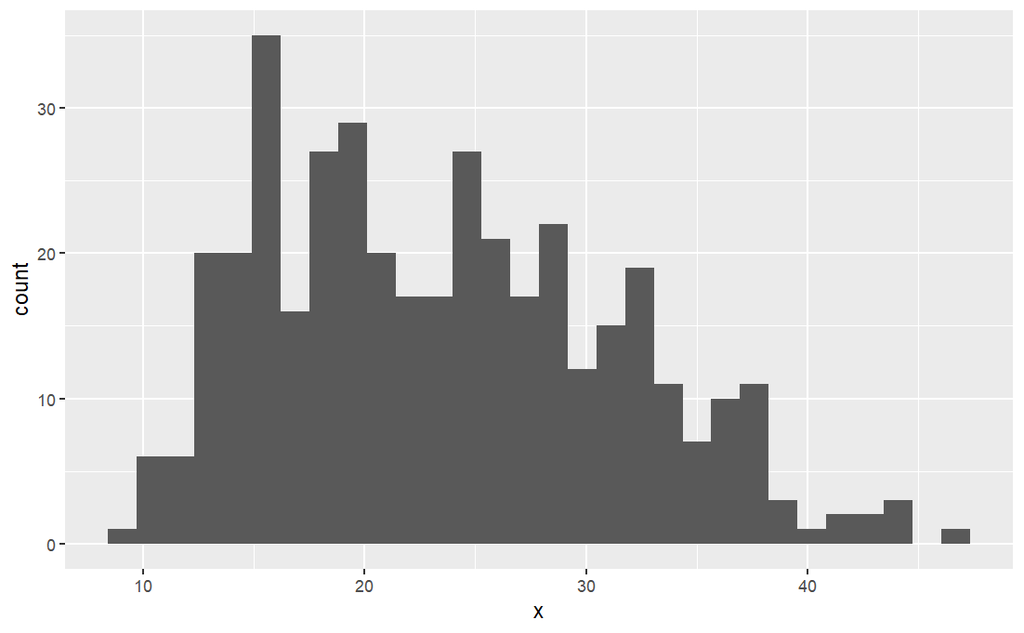

```r
univariate_analysis(df_auto$MPG)
```

Thus far, we have assumed the variable provided will be numeric. However, we should account for categorical variables. Update the “univariate_analysis” function: - If the provided vector is numeric, execute everything created in the function thus far (Hint: you can use is.numeric(data)==TRUE to evaluate this condition) - If the provided vector is character (is.character(data)==TRUE): - Store the number of elements in the vector in a variable named “obs” - Store the unique values of the vector in a variable named “unique_levels”. You can use unique(data) to calculate this. - Create a bar chart named “bar_chart” using the code provided below. This code plots the number of observations by the unique levels of the variable: bar_chart <- ggplot(data=data.frame(x=data), aes(x=x)) + geom_bar() - Returns the previous variables in a list with the elements named “obs”, “unique_levels”, and “bar_chart”)

```r
univariate_analysis <- function(data) {
  if(is.numeric(data) == TRUE) {
    obs = length(data)
    mean = mean(data, na.rm = TRUE)
    stdev = sd(data, na.rm = TRUE)
    quartiles = quantile(data, probs=c(0, 0.25, 0.5, 0.75, 1), na.rm = TRUE)
    histogram <- ggplot(data=data.frame(x=data), aes(x=x)) +  geom_histogram()
    return(list(obs, mean, stdev, quartiles, histogram))
  }

  else if(is.character(data) == TRUE) {
    obs = length(data)
    unique_levels = unique(data)
    bar_chart <- ggplot(data=data.frame(x=data), aes(x=x)) + geom_bar()
    return(list(obs, unique_levels, bar_chart))
  }
}
```

## Question 20

Using the function created, what is the median of “Displacement”? (Round your answer to 1 decimal place, example: nn.n)

```
[[1]]
[1] 398

[[2]]
[1] 193.4259

[[3]]
[1] 104.2698

[[4]]
    0%    25%    50%    75%   100%
 68.00 104.25 148.50 262.00 455.00

[[5]]
```

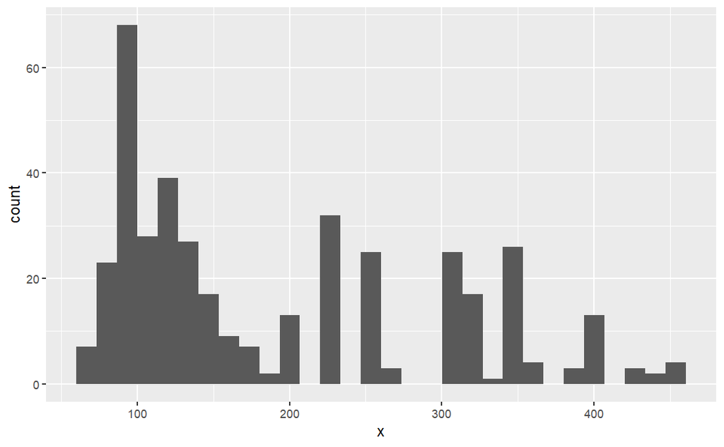

```r
univariate_analysis(df_auto$Displacement)
```

## Question 21

Using the function created, what is the most common number of cylinders for cars in the data set?

```
[[1]]
[1] 398

[[2]]
[1] "8" "4" "6" "3" "5"

[[3]]
```

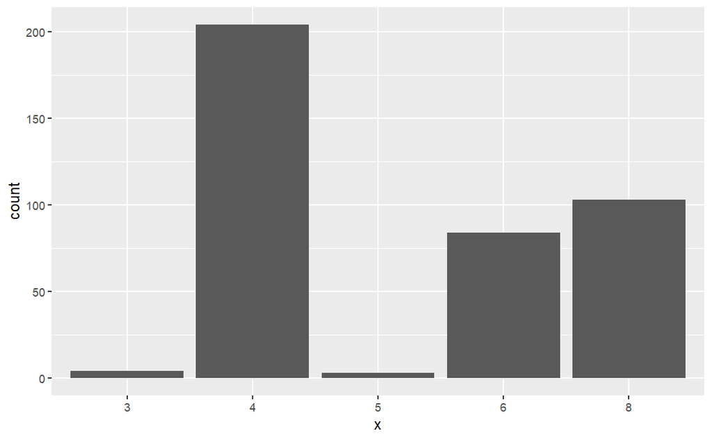

```r
univariate_analysis(df_auto$Cylinders)
```

# R Programming Part 2

For this portion of the assessment, we will be working with “traffic_stops_R.csv”. Read the “Traffic_stops_R.csv” data into R.

```r
traffic_raw <- read_csv('traffic_stops_R.csv')
```

```r
traffic <- traffic_raw %>% filter(driver_gender == 'female' & driver_age >60)
dim(traffic)
```

```
[1] 3763   10
```

```r
traffic <- traffic %>% mutate(weekday_of_stop = wday(mdy(stop_date)))
traffic <- traffic %>% filter(weekday_of_stop != 1)
```

## Question 22

How many observations does your new dataframe contains?

```r
dim(traffic)
```

```
[1] 3356   11
```

## Question 23

What is the most frequent driving violation in your new dataframe?

```r
traffic %>% count(violation)
```

| violation | n |
| --- | --- |
| Breaks-Lights-etc | 19 |
| Careless driving | 132 |
| License-Permit-Insurance | 202 |
| Other or unknown | 115 |
| Seat belt | 319 |
| Speeding | 2569 |